# UIDAI Data Hackathon 2026

## Comprehensive Biometric Lag Index (BLI) Analysis

### *Unlocking Societal Trends in Aadhaar Enrolment and Updates*

**Team:** BLI Analyzer | **Date:** January 2026 | **Records Analyzed:** 4,938,837

## Executive Summary

This notebook presents a comprehensive analysis of Aadhaar enrollment and biometric update patterns across India. We introduce the **Biometric Lag Index (BLI)** - a novel metric to identify children at risk of service denial due to outdated biometrics.

### Problem Statement

Children aged 5-17 are mandated to update their biometrics at ages 5, 10, and 15. However, a significant gap exists between enrollments and updates, potentially affecting millions of children's access to government services.

### Key Objectives

| # | Objective | Methodology |
| --- | --- | --- |
| 1 | Quantify the biometric update gap | Develop BLI metric |
| 2 | Identify high-risk geographic regions | Univariate & Geographic Analysis |
| 3 | Discover patterns affecting update rates | Bivariate & Trivariate Analysis |
| 4 | Segment districts by risk profile | K-Means Clustering |
| 5 | Provide actionable recommendations | Impact Quantification |

### Novel Contribution: Biometric Lag Index (BLI)

$$BLI = \frac{Enrollments_{5-17} - BiometricUpdates_{5-17}}{Enrollments_{5-17}}$$

| Risk Level | BLI Range | Recommended Action |
| --- | --- | --- |
| **Low** | < 0.1 | Routine monitoring |
| **Medium** | 0.1 - 0.3 | Awareness campaigns |
| **High** | 0.3 - 0.5 | Targeted intervention |
| **Critical** | > 0.5 | Immediate action required |

1. **Environment Setup** - Libraries and configuration
2. **Data Loading** - Import 4.9M records from 3 datasets
3. **Data Cleaning** - Handle duplicates, missing values, standardization
4. **Data Integration** - Merge datasets on common keys
5. **Feature Engineering** - Create BLI and derived metrics
6. **Univariate Analysis** - Distribution analysis of key variables
7. **Bivariate Analysis** - Correlations and statistical tests
8. **Trivariate Analysis** - Multi-dimensional insights
9. **Geographic Analysis** - State and district-level patterns
10. **Machine Learning** - Clustering and anomaly detection
11. **Time Series Analysis** - Temporal patterns
12. **Key Findings & Recommendations** - Actionable insights

# PART 1: ENVIRONMENT SETUP

## 1.1 Import Required Libraries

**Purpose:** Load all necessary Python libraries for data processing, statistical analysis, machine learning, and visualization.

| Category | Libraries |
| --- | --- |
| Data Processing | pandas, numpy, pathlib |
| Statistics | scipy.stats |
| Machine Learning | scikit-learn (KMeans, IsolationForest, RandomForest) |
| Visualization | matplotlib, seaborn, plotly |

```
✅ All libraries imported successfully!
📊 Pandas version: 2.3.3
🔢 NumPy version: 2.4.1
📈 Random seed set to: 42
```

# PART 2: DATA ACQUISITION

## 2.1 Load UIDAI Datasets

**Data Sources:** Official UIDAI API datasets provided for the hackathon

| Dataset | Records | Files | Key Columns |
| --- | --- | --- | --- |
| **Enrollment** | ~1,006,029 | 3 CSV | date, state, district, pincode, age_0_5, age_5_17, age_18_greater |
| **Biometric Updates** | ~1,861,108 | 4 CSV | date, state, district, pincode, bio_age_5_17, bio_age_17_ |
| **Demographic Updates** | ~2,071,700 | 5 CSV | date, state, district, pincode, demo_age_5_17, demo_age_17_ |
| **Total** | **4,938,837** | 12 CSV | - |

**Geographic Coverage:** Pan-India at pincode-level granularity

```
============================================================
LOADING ENROLLMENT DATA
============================================================

📁 Loading Enrollment data from 3 files...
```

```
   ✓ api_data_aadhar_enrolment_0_500000.csv: 500,000 rows
   ✓ api_data_aadhar_enrolment_1000000_1006029.csv: 6,029 rows
```

```
   ✓ api_data_aadhar_enrolment_500000_1000000.csv: 500,000 rows
   📊 Total Enrollment: 1,006,029 rows, 7 columns

============================================================
LOADING BIOMETRIC DATA
============================================================

📁 Loading Biometric data from 4 files...
```

```
   ✓ api_data_aadhar_biometric_0_500000.csv: 500,000 rows
```

```
   ✓ api_data_aadhar_biometric_1000000_1500000.csv: 500,000 rows
   ✓ api_data_aadhar_biometric_1500000_1861108.csv: 361,108 rows
```

```
   ✓ api_data_aadhar_biometric_500000_1000000.csv: 500,000 rows
   📊 Total Biometric: 1,861,108 rows, 6 columns

============================================================
LOADING DEMOGRAPHIC DATA
============================================================

📁 Loading Demographic data from 5 files...
```

```
   ✓ api_data_aadhar_demographic_0_500000.csv: 500,000 rows
```

```
   ✓ api_data_aadhar_demographic_1000000_1500000.csv: 500,000 rows
```

```
   ✓ api_data_aadhar_demographic_1500000_2000000.csv: 500,000 rows
   ✓ api_data_aadhar_demographic_2000000_2071700.csv: 71,700 rows
```

```
   ✓ api_data_aadhar_demographic_500000_1000000.csv: 500,000 rows
   📊 Total Demographic: 2,071,700 rows, 6 columns

============================================================
📊 DATA LOADING SUMMARY
============================================================
✅ Enrollment records:     1,006,029
✅ Biometric records:      1,861,108
✅ Demographic records:    2,071,700
───────────────────────────────────
📈 TOTAL RECORDS:          4,938,837
```

```
💾 Total memory usage: 1169.75 MB
```

```
============================================================
ENROLLMENT DATA - First 5 Rows
============================================================
```

|  | date | state | district | pincode | age_0_5 | age_5_17 | age_18_greater |
| --- | --- | --- | --- | --- | --- | --- | --- |
| 0 | 02-03-2025 | Meghalaya | East Khasi Hills | 793121 | 11 | 61 | 37 |
| 1 | 09-03-2025 | Karnataka | Bengaluru Urban | 560043 | 14 | 33 | 39 |
| 2 | 09-03-2025 | Uttar Pradesh | Kanpur Nagar | 208001 | 29 | 82 | 12 |
| 3 | 09-03-2025 | Uttar Pradesh | Aligarh | 202133 | 62 | 29 | 15 |
| 4 | 09-03-2025 | Karnataka | Bengaluru Urban | 560016 | 14 | 16 | 21 |

```
============================================================
BIOMETRIC DATA - First 5 Rows
============================================================
```

|  | date | state | district | pincode | bio_age_5_17 | bio_age_17_ |
| --- | --- | --- | --- | --- | --- | --- |
| 0 | 01-03-2025 | Haryana | Mahendragarh | 123029 | 280 | 577 |
| 1 | 01-03-2025 | Bihar | Madhepura | 852121 | 144 | 369 |
| 2 | 01-03-2025 | Jammu and Kashmir | Punch | 185101 | 643 | 1091 |
| 3 | 01-03-2025 | Bihar | Bhojpur | 802158 | 256 | 980 |
| 4 | 01-03-2025 | Tamil Nadu | Madurai | 625514 | 271 | 815 |

```
============================================================
DEMOGRAPHIC DATA - First 5 Rows
============================================================
```

|  | date | state | district | pincode | demo_age_5_17 | demo_age_17_ |
| --- | --- | --- | --- | --- | --- | --- |
| 0 | 01-03-2025 | Uttar Pradesh | Gorakhpur | 273213 | 49 | 529 |
| 1 | 01-03-2025 | Andhra Pradesh | Chittoor | 517132 | 22 | 375 |
| 2 | 01-03-2025 | Gujarat | Rajkot | 360006 | 65 | 765 |
| 3 | 01-03-2025 | Andhra Pradesh | Srikakulam | 532484 | 24 | 314 |
| 4 | 01-03-2025 | Rajasthan | Udaipur | 313801 | 45 | 785 |

# PART 3: DATA PREPROCESSING

## 3.1 Data Cleaning Pipeline

**Objective:** Ensure data quality and consistency before analysis

| Step | Operation | Rationale |
| --- | --- | --- |
| 1 | Parse dates (DD-MM-YYYY) | Enable temporal analysis |
| 2 | Standardize text fields | Ensure consistent matching across datasets |
| 3 | Remove duplicates | Avoid double-counting in aggregations |
| 4 | Handle missing values | Maintain data integrity |
| 5 | Validate data ranges | Identify potential data quality issues |

**Expected Output:** Clean datasets ready for merging

```
🧹 Cleaning Enrollment dataset...
```

```
   📊 Original rows: 1,006,029
   🔄 Duplicates removed: 23,029
   ✅ Final rows: 983,000
   📉 Missing values filled: 0

🧹 Cleaning Biometric dataset...
```

```
   📊 Original rows: 1,861,108
   🔄 Duplicates removed: 94,949
   ✅ Final rows: 1,766,159
   📉 Missing values filled: 0

🧹 Cleaning Demographic dataset...
```

```
   📊 Original rows: 2,071,700
   🔄 Duplicates removed: 473,688
   ✅ Final rows: 1,598,012
   📉 Missing values filled: 0

============================================================
DATA QUALITY ASSESSMENT
============================================================

📋 Enrollment Data Types:
date              datetime64[ns]
state                     object
district                  object
pincode                   object
age_0_5                    int64
age_5_17                   int64
age_18_greater             int64
dtype: object

🔍 Missing Values:
date              0
state             0
district          0
pincode           0
age_0_5           0
age_5_17          0
age_18_greater    0
dtype: int64

📋 Biometric Data Types:
date            datetime64[ns]
state                   object
district                object
pincode                 object
bio_age_5_17             int64
bio_age_17_              int64
dtype: object

🔍 Missing Values:
```

```
date            0
state           0
district        0
pincode         0
bio_age_5_17    0
bio_age_17_     0
dtype: int64

📋 Demographic Data Types:
date             datetime64[ns]
state                    object
district                 object
pincode                  object
demo_age_5_17             int64
demo_age_17_              int64
dtype: object

🔍 Missing Values:
date             0
state            0
district         0
pincode          0
demo_age_5_17    0
demo_age_17_     0
dtype: int64
```

## 3.2 Data Integration (Merging)

**Objective:** Create a unified dataset by joining enrollment, biometric, and demographic data

**Merge Strategy:**

```
Enrollment Data ──┬── OUTER JOIN ──► Enrollment + Biometric
                  │     on: (date, state, district, pincode)
Biometric Data ───┘
                                              │
                                              ▼
                                     LEFT JOIN ──► Final Merged Dataset
                                              │
Demographic Data ─────────────────────────────┘
```

**Expected Output:** Single dataset with all columns from all three sources

```
============================================================
MERGING DATASETS
============================================================

📊 Step 1: Merging Enrollment + Biometric...
   Enrollment rows: 983,000
   Biometric rows: 1,766,159
```

```
   Merge results:
_merge_enr_bio
right_only    1039274
both           727919
left_only      256714
Name: count, dtype: int64

📊 Step 2: Merging with Demographic...
   Current merged rows: 2,023,907
   Demographic rows: 1,598,012
```

```
   Merge results:
_merge_demo
both          1295496
left_only      731213
right_only          0
Name: count, dtype: int64
```

```
============================================================
📊 FINAL MERGED DATASET SUMMARY
============================================================

✅ Total merged records: 2,026,709
✅ Total columns: 11

📋 Columns: ['date', 'state', 'district', 'pincode', 'age_0_5', 'age_5_17', 'age_18_greater', 'bio_age_5_17', 'bio_age_17_', 'demo_age_5_17', 'demo_age_17_']

📅 Date range: 2025-03-01 00:00:00 to 2025-12-31 00:00:00
🗺️ Unique states: 52
🏙️ Unique districts: 982
```

```
📍 Unique pincodes: 19730
```

```
💾 Memory usage: 455.58 MB
```

# PART 4: FEATURE ENGINEERING

## 4.1 Biometric Lag Index (BLI) Calculation

**Core Innovation:** The BLI metric quantifies the proportion of children with outdated biometrics

### Formula

$$BLI = \frac{Enrollments_{5-17} - BiometricUpdates_{5-17}}{Enrollments_{5-17}}$$

### Risk Classification Matrix

| Risk Level | BLI Range | Color Code | Interpretation | Action |
| --- | --- | --- | --- | --- |
| **Low** | < 0.1 | 🟢 Green | < 10% children have outdated biometrics | Routine monitoring |
| **Medium** | 0.1 - 0.3 | 🟡 Yellow | 10-30% children at risk | Awareness campaigns |
| **High** | 0.3 - 0.5 | 🟠 Orange | 30-50% children at risk | Targeted intervention |
| **Critical** | > 0.5 | 🔴 Red | > 50% children at risk | Immediate action required |

### Additional Derived Features

| Feature | Formula | Purpose |
| --- | --- | --- |
| child_update_gap | age_5_17 - bio_age_5_17 | Absolute count of children needing updates |
| biometric_update_rate | bio_age_5_17 / age_5_17 | Compliance rate |
| total_enrollments | age_0_5 + age_5_17 + age_18_greater | Overall enrollment volume |
| Temporal features | year, month, week | Time series analysis |

```
============================================================
CREATING DERIVED METRICS
============================================================
```

```
✅ Derived columns created:
   • child_update_gap: Gap between enrollment and biometric updates
   • bli_score: Biometric Lag Index (0-1 scale)
   • total_enrollments: Sum of all age groups
   • biometric_update_rate: Proportion of children who updated
   • risk_level: Categorical classification (Low/Medium/High/Critical)
   • Temporal features: year, month, day_of_week, week_of_year

============================================================
📊 BLI SCORE DISTRIBUTION
============================================================
count       2026709.0000
mean      -13024748.6725
std        72038960.4615
min     -8002000000.0000
25%        -5000000.0000
50%        -1000000.0000
75%               0.0000
max               1.0000
Name: bli_score, dtype: float64

📊 Risk Level Distribution:
risk_level
Low         1895428
Critical     118671
High           9318
Medium         3292
Name: count, dtype: int64

📊 Risk Level Percentages:
risk_level
Low        93.5200
Critical    5.8600
High        0.4600
Medium      0.1600
Name: proportion, dtype: float64
```

# PART 5: UNIVARIATE ANALYSIS

## 5.1 Enrollment Distribution Analysis

**Objective:** Understand the distribution characteristics of individual variables

### Analysis Components

| Analysis | Variables | Techniques |
| --- | --- | --- |
| Central Tendency | Mean, Median, Mode | Identify typical values |
| Dispersion | Std Dev, IQR, Range | Measure variability |
| Shape | Skewness, Kurtosis | Distribution characteristics |
| Outliers | Z-score, IQR method | Identify anomalies |

### Key Variables Analyzed

1. **age_0_5** - Children aged 0-5 (newly enrolled)
2. **age_5_17** - Children aged 5-17 (TARGET GROUP for biometric updates)
3. **age_18_greater** - Adults enrolled
4. **total_enrollments** - Sum of all age groups

```
============================================================
UNIVARIATE ANALYSIS: ENROLLMENT DATA
============================================================

📊 Descriptive Statistics for Enrollment Columns:
```

|  | age_0_5 | age_5_17 | age_18_greater | total_enrollments |
| --- | --- | --- | --- | --- |
| count | 2026709.0000 | 2026709.0000 | 2026709.0000 | 2026709.0000 |
| mean | 1.7199 | 0.8362 | 0.0822 | 2.6383 |
| std | 12.4749 | 10.1561 | 2.2693 | 22.4071 |
| min | 0.0000 | 0.0000 | 0.0000 | 0.0000 |
| 25% | 0.0000 | 0.0000 | 0.0000 | 0.0000 |
| 50% | 0.0000 | 0.0000 | 0.0000 | 0.0000 |
| 75% | 1.0000 | 0.0000 | 0.0000 | 2.0000 |
| max | 2688.0000 | 1812.0000 | 855.0000 | 3965.0000 |
| skewness | 61.0145 | 59.1653 | 124.7489 | 54.7306 |
| kurtosis | 6060.6786 | 4950.8334 | 26033.2336 | 4579.5587 |

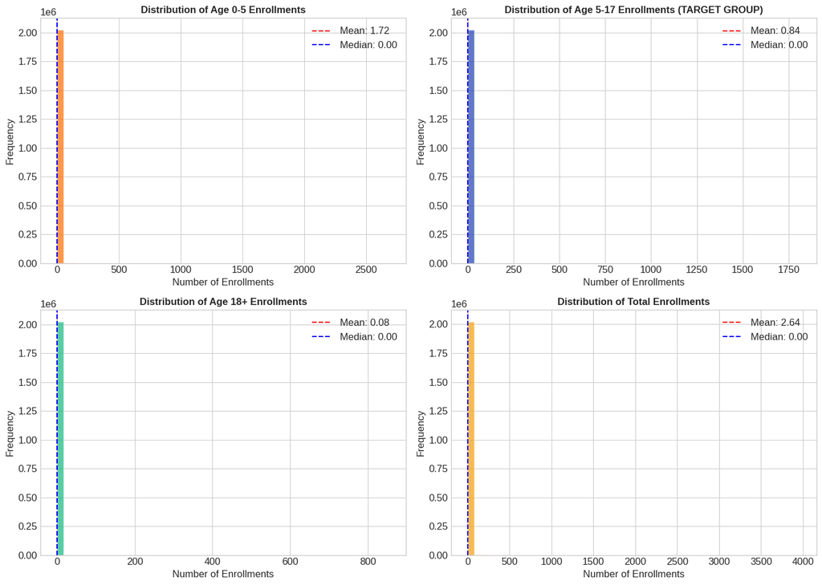

```
✅ Figure saved: univariate_enrollment_distribution.png
```

```
============================================================
STATE-WISE ENROLLMENT ANALYSIS
============================================================

📊 Top 20 States by Total Enrollment:
```

|  | state | age_0_5 | age_5_17 | age_18_greater | total_enrollments |
| --- | --- | --- | --- | --- | --- |
| 45 | Uttar Pradesh | 511727.0000 | 473205.0000 | 17699.0000 | 1002631.0000 |
| 6 | Bihar | 254911.0000 | 327043.0000 | 11799.0000 | 593753.0000 |
| 27 | Madhya Pradesh | 363244.0000 | 115172.0000 | 9476.0000 | 487892.0000 |
| 50 | West Bengal | 271401.0000 | 90615.0000 | 8500.0000 | 370516.0000 |
| 28 | Maharashtra | 274274.0000 | 81069.0000 | 8103.0000 | 363446.0000 |
| 38 | Rajasthan | 224977.0000 | 110131.0000 | 5483.0000 | 340591.0000 |
| 17 | Gujarat | 188709.0000 | 70270.0000 | 16063.0000 | 275042.0000 |
| 23 | Karnataka | 181536.0000 | 34759.0000 | 10128.0000 | 226423.0000 |
| 5 | Assam | 137970.0000 | 64834.0000 | 22555.0000 | 225359.0000 |
| 40 | Tamil Nadu | 178294.0000 | 36214.0000 | 1202.0000 | 215710.0000 |
| 22 | Jharkhand | 99874.0000 | 57971.0000 | 1460.0000 | 159305.0000 |
| 42 | Telangana | 103768.0000 | 24035.0000 | 1145.0000 | 128948.0000 |
| 3 | Andhra Pradesh | 109484.0000 | 13433.0000 | 1465.0000 | 124382.0000 |
| 33 | Odisha | 95145.0000 | 21887.0000 | 753.0000 | 117785.0000 |
| 30 | Meghalaya | 21072.0000 | 53089.0000 | 35078.0000 | 109239.0000 |
| 9 | Chhattisgarh | 79653.0000 | 18158.0000 | 1962.0000 | 99773.0000 |
| 18 | Haryana | 85112.0000 | 8897.0000 | 1076.0000 | 95085.0000 |
| 15 | Delhi | 67844.0000 | 21971.0000 | 3023.0000 | 92838.0000 |
| 37 | Punjab | 60481.0000 | 12175.0000 | 3117.0000 | 75773.0000 |
| 24 | Kerala | 52950.0000 | 18360.0000 | 2640.0000 | 73950.0000 |

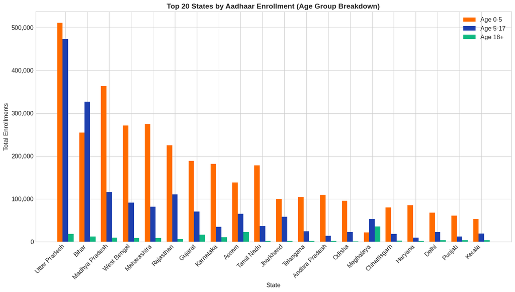

```
✅ Figure saved: top_20_states_enrollment.png
```

## 5.2 Biometric Update Distribution

**Focus:** Analyzing the distribution of biometric update data - the key metric for identifying children at risk

### Key Metrics Analyzed

| Metric | Description | Importance |
| --- | --- | --- |
| **bio_age_5_17** | Count of children who updated biometrics | Direct measure of compliance |
| **biometric_update_rate** | bio_age_5_17 / age_5_17 | Normalized compliance rate |
| **child_update_gap** | age_5_17 - bio_age_5_17 | Absolute count at risk |
| **bli_score** | Biometric Lag Index | Our novel metric |

```
============================================================
UNIVARIATE ANALYSIS: BIOMETRIC UPDATE DATA
============================================================

📊 Descriptive Statistics for Biometric Columns:
```

|  | bio_age_5_17 | biometric_update_rate | child_update_gap | bio_age_17_ |
| --- | --- | --- | --- | --- |
| count | 2026709.0000 | 2026709.0000 | 2026709.0000 | 2026709.0000 |
| mean | 16.5195 | 13024748.8900 | -15.6833 | 17.1877 |
| std | 80.3620 | 72038960.4222 | 78.0487 | 84.5587 |
| min | 0.0000 | 0.0000 | -8002.0000 | 0.0000 |
| 25% | 0.0000 | 0.0000 | -8.0000 | 1.0000 |
| 50% | 3.0000 | 1000000.0000 | -2.0000 | 3.0000 |
| 75% | 9.0000 | 5000000.0000 | 0.0000 | 9.0000 |
| max | 8002.0000 | 8002000000.0000 | 1472.0000 | 7625.0000 |
| skewness | 20.1261 | 19.8246 | -19.5038 | 18.8186 |
| kurtosis | 768.9926 | 783.3520 | 740.1190 | 660.0140 |

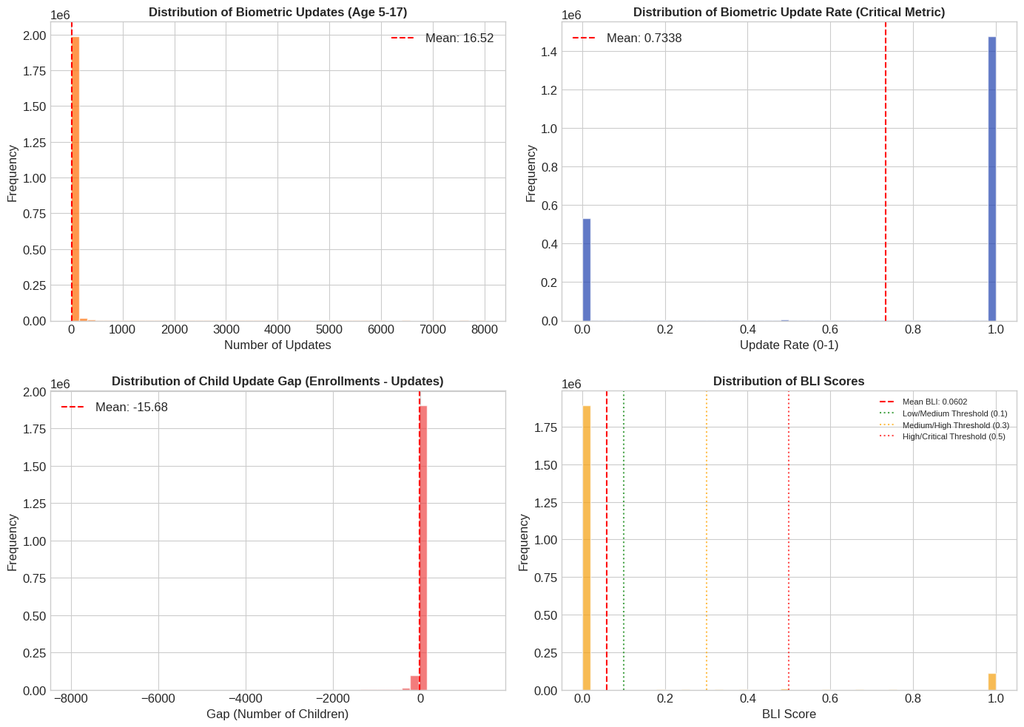

```
✅ Figure saved: univariate_biometric_distribution.png
```

## 5.3 State-Level BLI Analysis

**Purpose:** Aggregate pincode-level data to state level for strategic insights

### Aggregation Method

```
state_bli = df_merged.groupby('state').agg({
    'age_5_17': 'sum',           # Total children enrolled
    'bio_age_5_17': 'sum',       # Total children with updated biometrics
    'child_update_gap': 'sum',   # Total children at risk
}).reset_index()

state_bli['state_bli'] = child_update_gap / age_5_17  # State-level BLI
```

### Visualizations Generated

1. **Box Plot**: BLI distribution by state with risk thresholds
2. **Pie Chart**: State-level risk category distribution

```
============================================================
STATE-WISE BLI DISTRIBUTION (BOX PLOTS)
============================================================

📊 State-Level BLI Summary:
```

|  | state | age_5_17 | bio_age_5_17 | child_update_gap | total_enrollments | state_bli | risk_level |
| --- | --- | --- | --- | --- | --- | --- | --- |
| 43 | The Dadra And Nagar Haveli And Daman And Diu | 141.0000 | 0.0000 | 141.0000 | 716.0000 | 1.0000 | Critical |
| 0 | 100000 | 1.0000 | 0.0000 | 1.0000 | 214.0000 | 1.0000 | Critical |
| 30 | Meghalaya | 53089.0000 | 35911.0000 | 17178.0000 | 109239.0000 | 0.3236 | High |
| 48 | West Bengal | 6.0000 | 5.0000 | 1.0000 | 15.0000 | 0.1667 | Medium |
| 47 | Uttaranchal | 0.0000 | 0.0000 | 0.0000 | 0.0000 | 0.0000 | Low |
| 51 | Westbengal | 3.0000 | 7.0000 | -4.0000 | 7.0000 | -1.3333 | Low |
| 32 | Nagaland | 9856.0000 | 32005.0000 | -22149.0000 | 15429.0000 | -2.2473 | Low |
| 49 | West Bangal | 3.0000 | 14.0000 | -11.0000 | 10.0000 | -3.6667 | Low |
| 20 | Jammu & Kashmir | 20.0000 | 107.0000 | -87.0000 | 146.0000 | -4.3500 | Low |
| 6 | Bihar | 327043.0000 | 2160544.0000 | -1833501.0000 | 593753.0000 | -5.6063 | Low |
| 5 | Assam | 64834.0000 | 574106.0000 | -509272.0000 | 225359.0000 | -7.8550 | Low |
| 50 | West Bengal | 90615.0000 | 1024548.0000 | -933933.0000 | 370516.0000 | -10.3066 | Low |
| 39 | Sikkim | 1030.0000 | 11801.0000 | -10771.0000 | 2175.0000 | -10.4573 | Low |
| 45 | Uttar Pradesh | 473205.0000 | 6076420.0000 | -5603215.0000 | 1002631.0000 | -11.8410 | Low |
| 22 | Jharkhand | 57971.0000 | 874031.0000 | -816060.0000 | 159305.0000 | -14.0770 | Low |
| 38 | Rajasthan | 110131.0000 | 2032783.0000 | -1922652.0000 | 340591.0000 | -17.4579 | Low |
| 4 | Arunachal Pradesh | 2176.0000 | 41143.0000 | -38967.0000 | 4240.0000 | -17.9076 | Low |
| 17 | Gujarat | 70270.0000 | 1437932.0000 | -1367662.0000 | 275042.0000 | -19.4630 | Low |
| 29 | Manipur | 7895.0000 | 162366.0000 | -154471.0000 | 13199.0000 | -19.5657 | Low |
| 25 | Ladakh | 133.0000 | 2752.0000 | -2619.0000 | 617.0000 | -19.6917 | Low |
| 34 | Orissa | 580.0000 | 12570.0000 | -11990.0000 | 4054.0000 | -20.6724 | Low |
| 10 | Dadra & Nagar Haveli | 3.0000 | 69.0000 | -66.0000 | 25.0000 | -22.0000 | Low |
| 15 | Delhi | 21971.0000 | 545395.0000 | -523424.0000 | 92838.0000 | -23.8234 | Low |
| 27 | Madhya Pradesh | 115172.0000 | 3148670.0000 | -3033498.0000 | 487892.0000 | -26.3388 | Low |
| 24 | Kerala | 18360.0000 | 637862.0000 | -619502.0000 | 73950.0000 | -33.7419 | Low |
| 23 | Karnataka | 34759.0000 | 1236790.0000 | -1202031.0000 | 226423.0000 | -34.5819 | Low |
| 12 | Dadra And Nagar Haveli And Daman And Diu | 20.0000 | 747.0000 | -727.0000 | 169.0000 | -36.3500 | Low |
| 42 | Telangana | 24035.0000 | 909878.0000 | -885843.0000 | 128948.0000 | -36.8564 | Low |
| 44 | Tripura | 3597.0000 | 144132.0000 | -140535.0000 | 11008.0000 | -39.0701 | Low |
| 28 | Maharashtra | 81069.0000 | 3437083.0000 | -3356014.0000 | 363446.0000 | -41.3970 | Low |
| 9 | Chhattisgarh | 18158.0000 | 839392.0000 | -821234.0000 | 99773.0000 | -45.2271 | Low |
| 21 | Jammu And Kashmir | 7782.0000 | 406650.0000 | -398868.0000 | 47494.0000 | -51.2552 | Low |
| 33 | Odisha | 21887.0000 | 1178110.0000 | -1156223.0000 | 117785.0000 | -52.8269 | Low |
| 37 | Punjab | 12175.0000 | 689963.0000 | -677788.0000 | 75773.0000 | -55.6705 | Low |
| 40 | Tamil Nadu | 36214.0000 | 2153302.0000 | -2117088.0000 | 215710.0000 | -58.4605 | Low |
| 35 | Pondicherry | 79.0000 | 5133.0000 | -5054.0000 | 1260.0000 | -63.9747 | Low |
| 31 | Mizoram | 1259.0000 | 84746.0000 | -83487.0000 | 5774.0000 | -66.3122 | Low |
| 46 | Uttarakhand | 5410.0000 | 408293.0000 | -402883.0000 | 36956.0000 | -74.4701 | Low |
| 18 | Haryana | 8897.0000 | 676864.0000 | -667967.0000 | 95085.0000 | -75.0778 | Low |
| 1 | Andaman & Nicobar Islands | 5.0000 | 382.0000 | -377.0000 | 111.0000 | -75.4000 | Low |
| 16 | Goa | 253.0000 | 33143.0000 | -32890.0000 | 2280.0000 | -130.0000 | Low |
| 11 | Dadra And Nagar Haveli | 70.0000 | 10692.0000 | -10622.0000 | 738.0000 | -151.7429 | Low |
| 3 | Andhra Pradesh | 13433.0000 | 2181823.0000 | -2168390.0000 | 124382.0000 | -161.4226 | Low |
| 36 | Puducherry | 114.0000 | 21389.0000 | -21275.0000 | 1723.0000 | -186.6228 | Low |
| 26 | Lakshadweep | 10.0000 | 2195.0000 | -2185.0000 | 199.0000 | -218.5000 | Low |
| 7 | Chandigarh | 210.0000 | 48687.0000 | -48477.0000 | 2620.0000 | -230.8429 | Low |
| 19 | Himachal Pradesh | 650.0000 | 184098.0000 | -183448.0000 | 16909.0000 | -282.2277 | Low |
| 14 | Daman And Diu | 13.0000 | 4178.0000 | -4165.0000 | 113.0000 | -320.3846 | Low |
| 2 | Andaman And Nicobar Islands | 27.0000 | 10972.0000 | -10945.0000 | 390.0000 | -405.3704 | Low |
| 13 | Daman & Diu | 1.0000 | 528.0000 | -527.0000 | 21.0000 | -526.9995 | Low |
| 41 | Tamilnadu | 0.0000 | 1.0000 | -1.0000 | 0.0000 | -1000000.0000 | Low |
| 8 | Chhatisgarh | 0.0000 | 2.0000 | -2.0000 | 0.0000 | -2000000.0000 | Low |

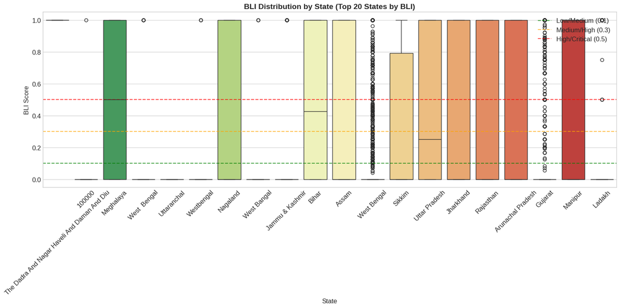

```
✅ Figure saved: bli_boxplot_by_state.png
```

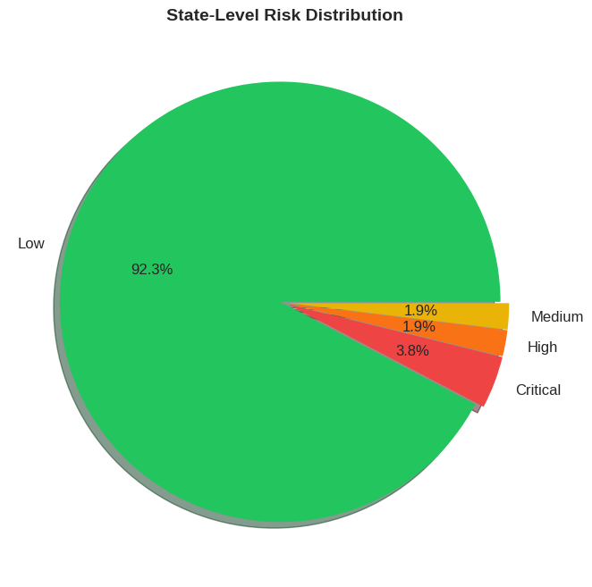

```
✅ Figure saved: state_risk_pie_chart.png
```

## 5.4 Outlier Detection

**Purpose:** Identify anomalous records that may indicate data quality issues or exceptional cases requiring investigation

### Detection Methods

| Method | Formula | Threshold |
| --- | --- | --- |
| **IQR Method** | Q1 - 1.5×IQR < x < Q3 + 1.5×IQR | 1.5 × IQR |
| **Z-Score Method** | \|z\| = \|(x - μ) / σ\| | z > 3 |

### Variables Analyzed

- `age_5_17` - Enrollment counts
- `bio_age_5_17` - Update counts
- `child_update_gap` - Gap values
- `bli_score` - BLI metric

```
============================================================
OUTLIER DETECTION ANALYSIS
============================================================
```

```
📊 Analyzing age_5_17...
   IQR Method: 44,646 outliers (7.73%)
   Z-Score Method: 1,049 outliers (0.18%)

📊 Analyzing bio_age_5_17...
   IQR Method: 46,429 outliers (8.04%)
   Z-Score Method: 940 outliers (0.16%)

📊 Analyzing child_update_gap...
   IQR Method: 131,666 outliers (22.80%)
   Z-Score Method: 1,078 outliers (0.19%)

📊 Analyzing bli_score...
   IQR Method: 131,666 outliers (22.80%)
   Z-Score Method: 0 outliers (0.00%)

📊 OUTLIER DETECTION SUMMARY:
```

|  | Column | IQR Outliers | IQR Outlier % | Z-Score Outliers (\|z\|>3) | Z-Score Outlier % | IQR Lower Bound | IQR Upper Bound |
| --- | --- | --- | --- | --- | --- | --- | --- |
| 0 | age_5_17 | 44646 | 7.73% | 1049 | 0.18% | -1.5000 | 2.5000 |
| 1 | bio_age_5_17 | 46429 | 8.04% | 940 | 0.16% | 0.0000 | 0.0000 |
| 2 | child_update_gap | 131666 | 22.80% | 1078 | 0.19% | 0.0000 | 0.0000 |
| 3 | bli_score | 131666 | 22.80% | 0 | 0.00% | 0.0000 | 0.0000 |

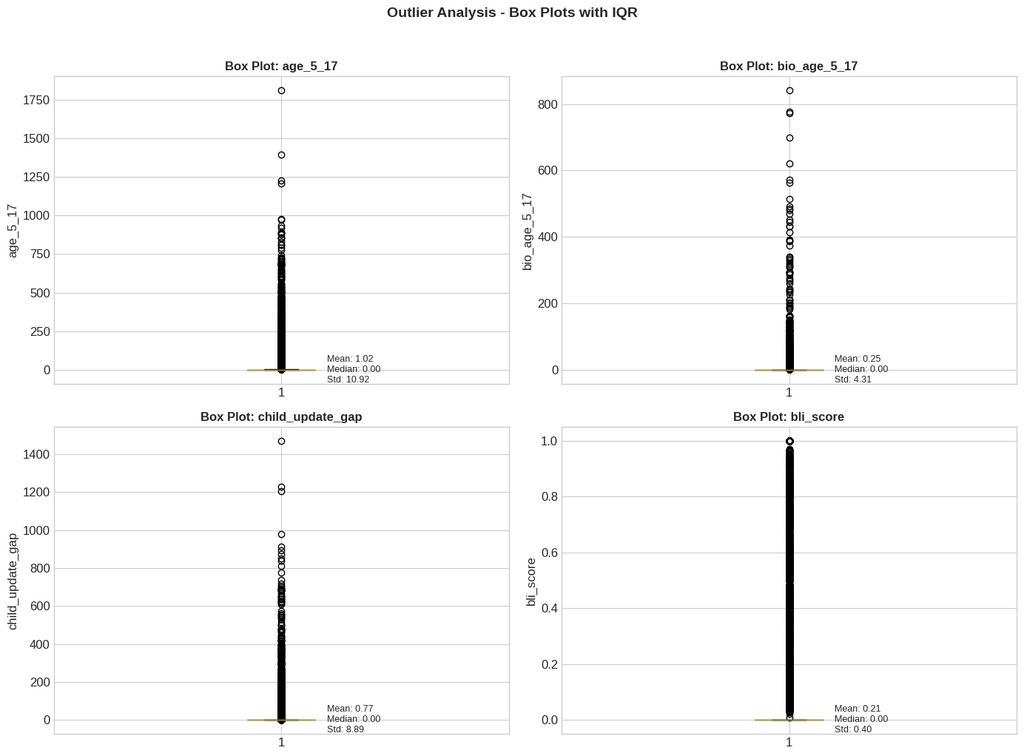

```
✅ Figure saved: outlier_detection_boxplots.png
```

## PART 6: BIVARIATE ANALYSIS

### 6.1 Correlation Matrix Analysis

**Objective:** Quantify pairwise relationships between all numerical variables using Pearson correlation coefficients.

| Correlation Strength | Range | Interpretation |
| --- | --- | --- |
| Very Strong | 0.8 - 1.0 | Near-perfect linear relationship |
| Strong | 0.6 - 0.8 | Significant predictive power |
| Moderate | 0.4 - 0.6 | Notable association |
| Weak | 0.2 - 0.4 | Minor relationship |
| Negligible | 0.0 - 0.2 | No meaningful correlation |

**Key Variable Pairs to Examine:**

- **Enrollments ↔ BLI** - Does higher enrollment volume correlate with higher/lower lag?
- **Age Groups ↔ Updates** - Which age cohorts have strongest update correlations?
- **Geographic ↔ Performance** - Do infrastructure indicators relate to outcomes?

**Statistical Output:**

- Pearson correlation matrix (all numeric variables)
- Heatmap visualization with significance annotations
- Top 10 strongest correlations identified

```
============================================================
BIVARIATE ANALYSIS: CORRELATION MATRIX
============================================================
```

```
📊 Pearson Correlation Matrix:
```

|  | age_0_5 | age_5_17 | age_18_greater | total_enrollments | bio_age_5_17 | child_update_gap | bli_score | biometric_update_rate | demo_age_5_17 | demographic_update_rate | bio_age_17_ |
| --- | --- | --- | --- | --- | --- | --- | --- | --- | --- | --- | --- |
| age_0_5 | 1.0000 | 0.7100 | 0.3333 | 0.8666 | 0.3424 | 0.7069 | 0.1117 | 0.0396 | 0.1522 | 0.0548 | 0.3008 |
| age_5_17 | 0.7100 | 1.0000 | 0.5888 | 0.9512 | 0.6261 | 0.9259 | 0.1260 | 0.0733 | 0.0642 | -0.0256 | 0.5170 |
| age_18_greater | 0.3333 | 0.5888 | 1.0000 | 0.6445 | 0.3802 | 0.5396 | 0.0359 | 0.0196 | 0.0041 | -0.0068 | 0.2535 |
| total_enrollments | 0.8666 | 0.9512 | 0.6445 | 1.0000 | 0.5551 | 0.9004 | 0.1221 | 0.0603 | 0.0994 | 0.0076 | 0.4548 |
| bio_age_5_17 | 0.3424 | 0.6261 | 0.3802 | 0.5551 | 1.0000 | 0.2851 | 0.0050 | 0.1741 | 0.0835 | -0.0162 | 0.8217 |
| child_update_gap | 0.7069 | 0.9259 | 0.5396 | 0.9004 | 0.2851 | 1.0000 | 0.1525 | 0.0058 | 0.0385 | -0.0236 | 0.2373 |
| bli_score | 0.1117 | 0.1260 | 0.0359 | 0.1221 | 0.0050 | 0.1525 | 1.0000 | -0.0767 | 0.0762 | -0.1446 | -0.0322 |
| biometric_update_rate | 0.0396 | 0.0733 | 0.0196 | 0.0603 | 0.1741 | 0.0058 | -0.0767 | 1.0000 | 0.1269 | -0.0768 | 0.1607 |
| demo_age_5_17 | 0.1522 | 0.0642 | 0.0041 | 0.0994 | 0.0835 | 0.0385 | 0.0762 | 0.1269 | 1.0000 | 0.5557 | 0.0794 |
| demographic_update_rate | 0.0548 | -0.0256 | -0.0068 | 0.0076 | -0.0162 | -0.0236 | -0.1446 | -0.0768 | 0.5557 | 1.0000 | -0.0182 |
| bio_age_17_ | 0.3008 | 0.5170 | 0.2535 | 0.4548 | 0.8217 | 0.2373 | -0.0322 | 0.1607 | 0.0794 | -0.0182 | 1.0000 |

```
📊 Spearman Correlation Matrix:
```

|  | age_0_5 | age_5_17 | age_18_greater | total_enrollments | bio_age_5_17 | child_update_gap | bli_score | biometric_update_rate | demo_age_5_17 | demographic_update_rate | bio_age_17_ |
| --- | --- | --- | --- | --- | --- | --- | --- | --- | --- | --- | --- |
| age_0_5 | 1.0000 | 0.2480 | 0.0640 | 0.8671 | 0.1139 | 0.2374 | 0.2243 | 0.1066 | 0.1880 | 0.1639 | -0.4400 |
| age_5_17 | 0.2480 | 1.0000 | 0.1272 | 0.6100 | 0.4984 | 0.8898 | 0.8787 | 0.4933 | 0.1320 | 0.0544 | -0.0959 |
| age_18_greater | 0.0640 | 0.1272 | 1.0000 | 0.1716 | 0.0627 | 0.1238 | 0.1136 | 0.0577 | 0.0302 | 0.0170 | -0.0503 |
| total_enrollments | 0.8671 | 0.6100 | 0.1716 | 1.0000 | 0.3053 | 0.5520 | 0.5378 | 0.2981 | 0.2159 | 0.1685 | -0.4435 |
| bio_age_5_17 | 0.1139 | 0.4984 | 0.0627 | 0.3053 | 1.0000 | 0.1275 | 0.0644 | 0.9981 | 0.1886 | 0.1275 | 0.2934 |
| child_update_gap | 0.2374 | 0.8898 | 0.1238 | 0.5520 | 0.1275 | 1.0000 | 0.9936 | 0.1082 | 0.0784 | 0.0143 | -0.2122 |
| bli_score | 0.2243 | 0.8787 | 0.1136 | 0.5378 | 0.0644 | 0.9936 | 1.0000 | 0.0499 | 0.0611 | 0.0018 | -0.2440 |
| biometric_update_rate | 0.1066 | 0.4933 | 0.0577 | 0.2981 | 0.9981 | 0.1082 | 0.0499 | 1.0000 | 0.1831 | 0.1241 | 0.2882 |
| demo_age_5_17 | 0.1880 | 0.1320 | 0.0302 | 0.2159 | 0.1886 | 0.0784 | 0.0611 | 0.1831 | 1.0000 | 0.9866 | 0.0408 |
| demographic_update_rate | 0.1639 | 0.0544 | 0.0170 | 0.1685 | 0.1275 | 0.0143 | 0.0018 | 0.1241 | 0.9866 | 1.0000 | 0.0318 |
| bio_age_17_ | -0.4400 | -0.0959 | -0.0503 | -0.4435 | 0.2934 | -0.2122 | -0.2440 | 0.2882 | 0.0408 | 0.0318 | 1.0000 |

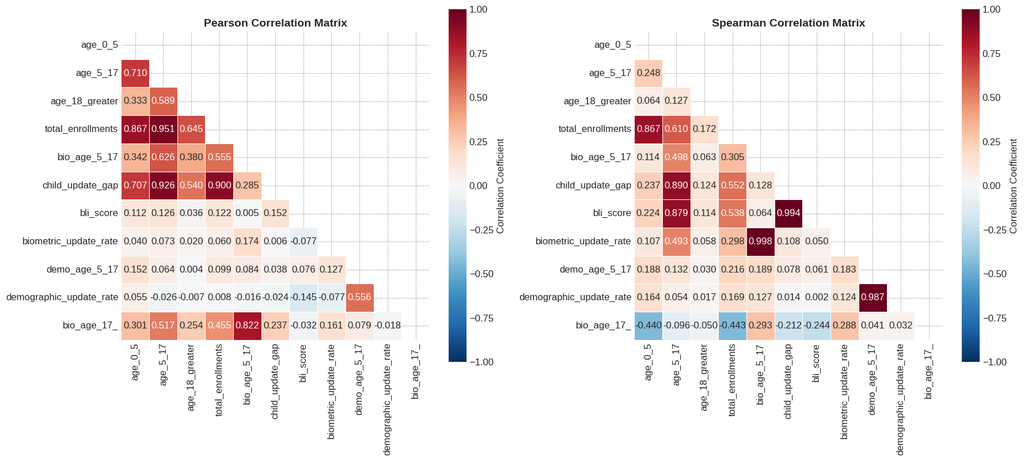

```
✅ Figure saved: correlation_matrices.png

============================================================
🔍 KEY CORRELATION INSIGHTS
============================================================

📊 Variables most correlated with BLI Score:
   child_update_gap: 0.1525
   demographic_update_rate: -0.1446
   age_5_17: 0.1260
   total_enrollments: 0.1221
   age_0_5: 0.1117
   biometric_update_rate: -0.0767
   demo_age_5_17: 0.0762
   age_18_greater: 0.0359
   bio_age_17_: -0.0322
   bio_age_5_17: 0.0050
```

## 6.2 Scatter Plots with Regression Analysis

**Purpose:** Visualize relationships and fit linear regression models to quantify associations

### Key Relationships Analyzed

[output not shown]

### Regression Statistics Reported

- **Slope (β₁)**: Change in Y per unit change in X
- **R²**: Variance explained by the model
- **p-value**: Statistical significance of relationship

```
============================================================
BIVARIATE ANALYSIS: SCATTER PLOTS WITH REGRESSION
============================================================
```

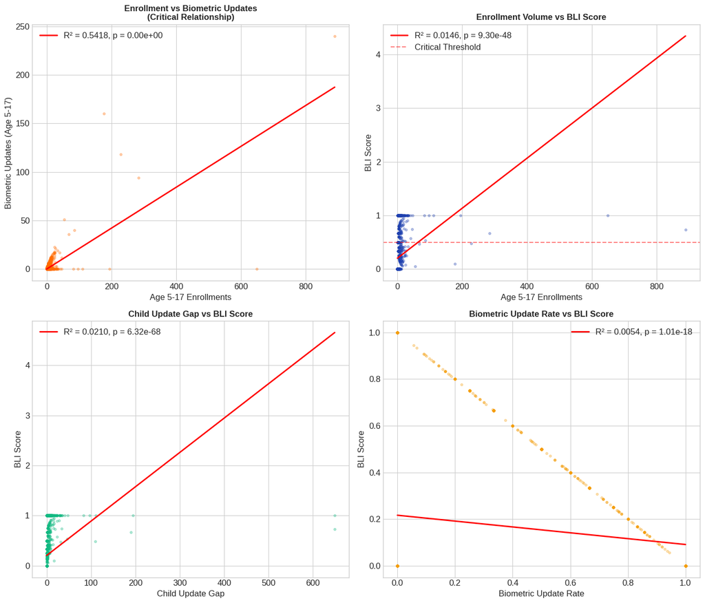

```
✅ Figure saved: bivariate_scatter_plots.png

============================================================
📊 REGRESSION ANALYSIS SUMMARY
============================================================

1. Enrollment vs Biometric Updates: R² = 0.5418, p-value = 0.00e+00
2. Enrollment vs BLI: R² = 0.0146, p-value = 9.30e-48
3. Child Update Gap vs BLI: R² = 0.0210, p-value = 6.32e-68
4. Update Rate vs BLI: R² = 0.0054, p-value = 1.01e-18
```

# PART 6: BIVARIATE ANALYSIS

## 6.1 Correlation Analysis

**Objective:** Identify relationships between variables to understand factors affecting biometric update rates

### Correlation Methods

| Method | Assumption | Best For |
| --- | --- | --- |
| **Pearson** | Linear relationship, normally distributed | Continuous variables |
| **Spearman** | Monotonic relationship | Ordinal or non-normal data |

### Variables Analyzed

- `age_5_17` ↔ `bio_age_5_17` (Enrollment vs Updates)
- `total_enrollments` ↔ `biometric_update_rate`
- `child_update_gap` ↔ `bli_score`
- All numeric features correlated with BLI

```
============================================================
STATISTICAL HYPOTHESIS TESTING
============================================================
```

```
📊 1. PEARSON CORRELATION TESTS
----------------------------------------
   Enrollments vs Biometric Updates: r = 0.6261, p = 0.00e+00 ***
   Enrollments vs BLI: r = 0.1260, p = 0.00e+00 ***
   Update Gap vs BLI: r = 0.1525, p = 0.00e+00 ***
   Age 0-5 Enrollments vs BLI: r = 0.1117, p = 0.00e+00 ***
```

|  | Variables | Pearson r | p-value | Significance | Interpretation |
| --- | --- | --- | --- | --- | --- |
| 0 | Enrollments vs Biometric Updates | 0.6261 | 0.00e+00 | *** | Strong |
| 1 | Enrollments vs BLI | 0.1260 | 0.00e+00 | *** | Weak |
| 2 | Update Gap vs BLI | 0.1525 | 0.00e+00 | *** | Weak |
| 3 | Age 0-5 Enrollments vs BLI | 0.1117 | 0.00e+00 | *** | Weak |

```
📊 2. SPEARMAN CORRELATION TESTS
----------------------------------------
   Enrollments vs Biometric Updates: ρ = 0.4984, p = 0.00e+00 ***
   Enrollments vs BLI: ρ = 0.8787, p = 0.00e+00 ***
```

```
   Update Gap vs BLI: ρ = 0.9936, p = 0.00e+00 ***
```

```
   Age 0-5 Enrollments vs BLI: ρ = 0.2243, p = 0.00e+00 ***
```

|  | Variables | Spearman ρ | p-value | Significance |
| --- | --- | --- | --- | --- |
| 0 | Enrollments vs Biometric Updates | 0.4984 | 0.00e+00 | *** |
| 1 | Enrollments vs BLI | 0.8787 | 0.00e+00 | *** |
| 2 | Update Gap vs BLI | 0.9936 | 0.00e+00 | *** |
| 3 | Age 0-5 Enrollments vs BLI | 0.2243 | 0.00e+00 | *** |

```
📊 3. INDEPENDENT T-TEST: High BLI vs Low BLI Districts
----------------------------------------

   Median BLI: 0.7788
   High BLI districts (BLI > median): 533
   Low BLI districts (BLI <= median): 534

   T-test (Total Enrollments): t = -2.5227, p = 1.18e-02
   High BLI mean enrollment: 1,359
   Low BLI mean enrollment: 1,714

📊 4. CHI-SQUARE TEST: State × Risk Level Association
----------------------------------------

Contingency Table (State × Risk Level):
```

| risk_level state | Critical | High | Low | Medium |
| --- | --- | --- | --- | --- |
| 100000 | 1 | 0 | 0 | 0 |
| Andaman & Nicobar Islands | 0 | 1 | 2 | 0 |
| Andaman And Nicobar Islands | 3 | 0 | 0 | 0 |
| Andhra Pradesh | 46 | 0 | 1 | 0 |
| Arunachal Pradesh | 21 | 3 | 1 | 0 |
| Assam | 37 | 1 | 0 | 0 |
| Bihar | 46 | 1 | 0 | 0 |
| Chandigarh | 1 | 0 | 2 | 0 |
| Chhatisgarh | 0 | 0 | 1 | 0 |
| Chhattisgarh | 40 | 0 | 0 | 0 |
| Dadra & Nagar Haveli | 1 | 0 | 0 | 0 |
| Dadra And Nagar Haveli | 1 | 0 | 0 | 0 |
| Dadra And Nagar Haveli And Daman And Diu | 3 | 0 | 0 | 0 |
| Daman & Diu | 0 | 0 | 2 | 0 |
| Daman And Diu | 2 | 0 | 0 | 0 |
| Delhi | 13 | 0 | 1 | 0 |
| Goa | 2 | 0 | 2 | 0 |
| Gujarat | 40 | 0 | 0 | 0 |
| Haryana | 26 | 0 | 1 | 0 |
| Himachal Pradesh | 11 | 1 | 2 | 0 |
| Jammu & Kashmir | 7 | 0 | 8 | 0 |
| Jammu And Kashmir | 24 | 0 | 1 | 0 |
| Jharkhand | 33 | 0 | 1 | 0 |
| Karnataka | 52 | 0 | 3 | 0 |
| Kerala | 15 | 0 | 0 | 0 |
| Ladakh | 2 | 0 | 0 | 0 |
| Lakshadweep | 1 | 0 | 0 | 0 |
| Madhya Pradesh | 61 | 0 | 0 | 0 |
| Maharashtra | 52 | 0 | 1 | 0 |
| Manipur | 12 | 0 | 0 | 0 |
| Meghalaya | 12 | 1 | 1 | 0 |
| Mizoram | 8 | 3 | 1 | 0 |
| Nagaland | 12 | 4 | 0 | 1 |
| Odisha | 40 | 0 | 0 | 0 |
| Orissa | 26 | 0 | 11 | 0 |
| Pondicherry | 3 | 0 | 2 | 0 |
| Puducherry | 3 | 0 | 1 | 0 |
| Punjab | 28 | 0 | 0 | 0 |
| Rajasthan | 38 | 0 | 7 | 0 |
| Sikkim | 9 | 1 | 0 | 0 |
| Tamil Nadu | 44 | 0 | 2 | 0 |
| Telangana | 42 | 0 | 0 | 0 |
| The Dadra And Nagar Haveli And Daman And Diu | 1 | 0 | 0 | 0 |
| Tripura | 8 | 0 | 1 | 0 |
| Uttar Pradesh | 89 | 0 | 3 | 0 |
| Uttarakhand | 15 | 0 | 0 | 0 |
| Uttaranchal | 0 | 0 | 2 | 0 |
| West Bengal | 1 | 0 | 0 | 0 |
| West Bangal | 2 | 0 | 1 | 0 |
| West Bengal | 46 | 1 | 6 | 0 |
| Westbengal | 1 | 0 | 1 | 0 |

```
   Chi-square statistic: 497.3515
   Degrees of freedom: 150
   p-value: 8.15e-39
   Conclusion: Significant association (p < 0.05)

📊 5. ONE-WAY ANOVA: BLI across Risk Levels
----------------------------------------
   F-statistic: 1124.0480
   p-value: 0.00e+00
   Conclusion: Significant differences between groups
```

# PART 7: TRIVARIATE ANALYSIS

## 7.1 State × District × BLI Interaction

**Objective:** Discover complex multi-dimensional patterns by analyzing three variables simultaneously

### Analysis Approach

[output not shown]

### Why Trivariate Analysis?

> *"Bivariate analysis may miss complex interactions that only emerge when examining three or more variables together."*

This analysis helps identify:

- **Clusters** of high-risk districts within states
- **Interactions** between enrollment volume and update behavior
- **Patterns** that inform targeted intervention strategies

```
============================================================
TRIVARIATE ANALYSIS: STATE × DISTRICT × BLI
============================================================
```

```
📊 Total districts analyzed: 113
📊 Total states: 34

📊 TOP 20 PROBLEM DISTRICTS (Highest BLI):
```

|  | state | district | bli | gap | enrollments_5_17 | risk_level |
| --- | --- | --- | --- | --- | --- | --- |
| 148 | Bihar | Purbi Champaran | 1.0000 | 10071.0000 | 10071.0000 | Critical |
| 403 | Karnataka | Bengaluru Urban | 1.0000 | 7167.0000 | 7167.0000 | Critical |
| 1032 | West Bengal | Dinajpur Uttar | 1.0000 | 4859.0000 | 4859.0000 | Critical |
| 989 | Uttar Pradesh | Siddharth Nagar | 1.0000 | 2586.0000 | 2586.0000 | Critical |
| 1017 | West Bengal | 24 Paraganas North | 1.0000 | 2458.0000 | 2458.0000 | Critical |
| 1027 | West Bengal | Coochbehar | 1.0000 | 2087.0000 | 2087.0000 | Critical |
| 987 | Uttar Pradesh | Shravasti | 1.0000 | 1570.0000 | 1570.0000 | Critical |
| 469 | Madhya Pradesh | Ashoknagar | 1.0000 | 1323.0000 | 1323.0000 | Critical |
| 958 | Uttar Pradesh | Kushi Nagar | 1.0000 | 777.0000 | 777.0000 | Critical |
| 43 | Andhra Pradesh | Spsr Nellore | 1.0000 | 713.0000 | 713.0000 | Critical |
| 283 | Haryana | Gurugram | 1.0000 | 625.0000 | 625.0000 | Critical |
| 365 | Jharkhand | East Singhbum | 1.0000 | 546.0000 | 546.0000 | Critical |
| 1050 | West Bengal | Medinipur West | 1.0000 | 300.0000 | 300.0000 | Critical |
| 181 | Chhattisgarh | Gaurella Pendra Marwahi | 1.0000 | 290.0000 | 290.0000 | Critical |
| 869 | Telangana | Medchal Malkajgiri | 1.0000 | 265.0000 | 265.0000 | Critical |
| 1031 | West Bengal | Dinajpur Dakshin | 1.0000 | 256.0000 | 256.0000 | Critical |
| 293 | Haryana | Nuh | 1.0000 | 213.0000 | 213.0000 | Critical |
| 248 | Gujarat | Dang | 1.0000 | 179.0000 | 179.0000 | Critical |
| 742 | Punjab | S.A.S Nagar | 1.0000 | 164.0000 | 164.0000 | Critical |
| 529 | Maharashtra | Ahmednagar | 1.0000 | 158.0000 | 158.0000 | Critical |

```
✅ Interactive 3D plot saved: trivariate_3d_scatter.html
```

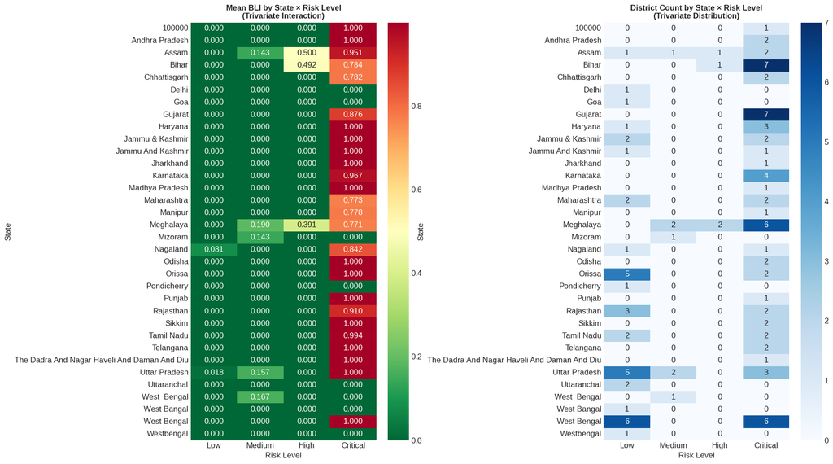

```
✅ Trivariate heatmap saved: trivariate_state_risk_heatmap.png
```

## 7.2 Age Group × State × Update Rate Analysis

**Purpose:** Understand how biometric update patterns vary across age groups and states simultaneously

### Three-Way Interaction Model

```
Update Rate = f(Age Group, State, Interaction)
```

| Age Group | Biometric Requirement | Update Importance |
| --- | --- | --- |
| 0-5 | Initial enrollment | Low (baseline) |
| 5-17 | Mandatory updates at 5, 10, 15 | **HIGH (Critical)** |
| 18+ | Adult updates | Medium |

### Expected Patterns

- States with high child population should show proportionally higher update activity
- Rural vs Urban differences may emerge in age-specific patterns

```
============================================================
TRIVARIATE: AGE GROUP × STATE × UPDATE RATE
============================================================
```

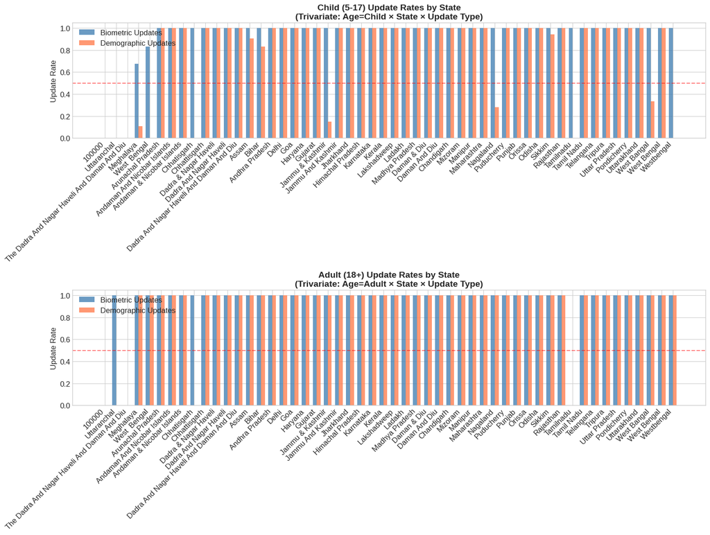

```
✅ Age × State × Update Rate trivariate chart saved: trivariate_age_state_update.png
```

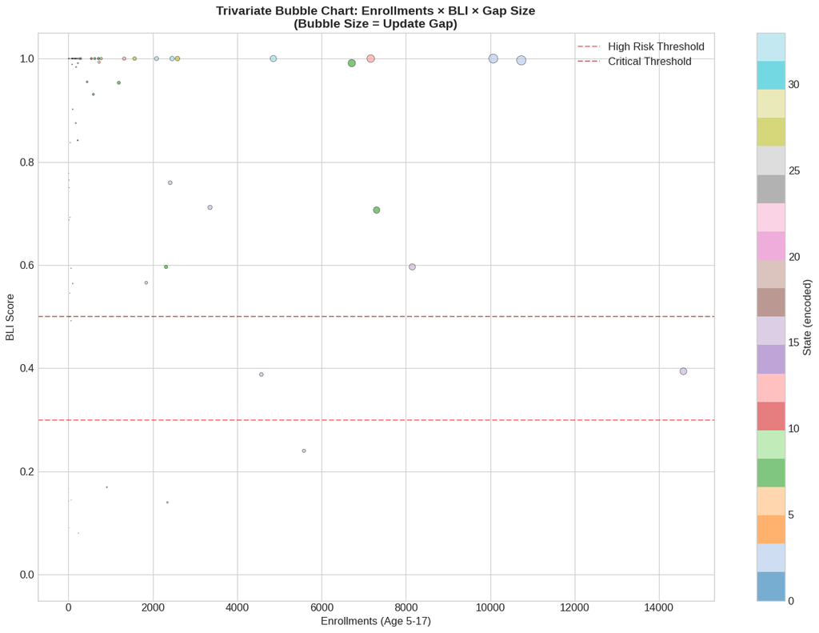

```
✅ Trivariate bubble charts saved
```

# PART 8: GEOGRAPHIC ANALYSIS

## 8.1 State-Level Geographic Visualization

**Purpose:** Visualize the spatial distribution of BLI across India's states

### Geographic Patterns to Identify

| Pattern Type | Description | Policy Implication |
| --- | --- | --- |
| **Regional Clusters** | Adjacent states with similar BLI | Regional intervention strategies |
| **North-South Divide** | Systematic differences by latitude | Differential resource allocation |
| **Urban-Rural Split** | Metro vs non-metro patterns | Targeted campaign design |

### Visualization Types

1. **Bar Chart** - State-wise BLI ranking
2. **Heatmap** - District density by risk level per state
3. **Choropleth** - Geographic distribution (if GeoJSON available)

```
============================================================
GEOGRAPHIC ANALYSIS: STATE-LEVEL VISUALIZATION
============================================================
```

```
📊 States analyzed: 5

📊 STATE-WISE BLI SUMMARY:
```

|  | State | BLI Score | Risk Level | Update Gap | Enrollments (5-17) | Districts |
| --- | --- | --- | --- | --- | --- | --- |
| 43 | The Dadra And Nagar Haveli And Daman And Diu | 1.0000 | Critical | 141.0000 | 141.0000 | 1 |
| 0 | 100000 | 1.0000 | Critical | 1.0000 | 1.0000 | 1 |
| 30 | Meghalaya | 0.3236 | High | 17178.0000 | 53089.0000 | 14 |
| 48 | West Bengal | 0.1667 | Medium | 1.0000 | 6.0000 | 1 |
| 47 | Uttaranchal | 0.0000 | Low | 0.0000 | 0.0000 | 2 |

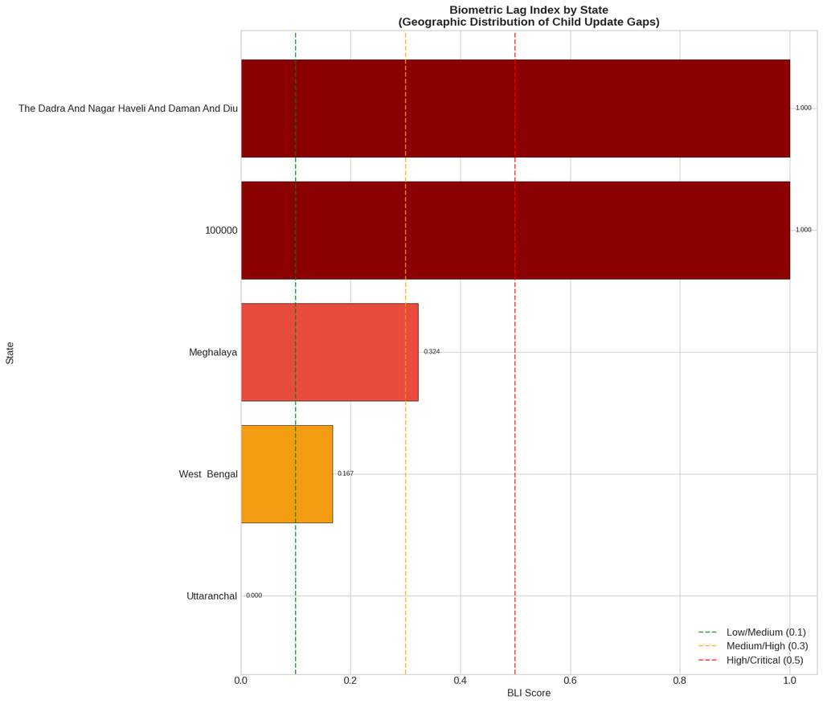

```
✅ Geographic state-level chart saved: geographic_state_bli.png
```

[figure not shown]

```
✅ District heatmap saved: geographic_district_heatmap.png
```

# PART 9: MACHINE LEARNING ANALYSIS

## 9.1 K-Means Clustering for District Segmentation

**Objective:** Segment districts into meaningful groups for targeted interventions

### Methodology

1. **Feature Selection**: enrollments_5_17, updates_5_17, bli, gap
2. **Standardization**: Z-score normalization for fair comparison
3. **Optimal K Selection**: Elbow method + Silhouette score
4. **Cluster Interpretation**: Profile each segment

### Expected Segments

| Cluster | Profile | Intervention Strategy |
| --- | --- | --- |
| 0 | Low BLI, High Updates | Best practices benchmark |
| 1 | High BLI, Low Updates | **Priority intervention** |
| 2 | Medium BLI, Growing | Monitor closely |
| 3 | High Enrollment, Variable BLI | Capacity building |

```
============================================================
ADVANCED ANALYTICS: K-MEANS CLUSTERING
============================================================
```

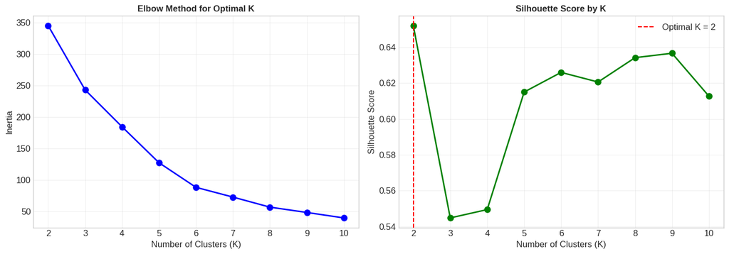

```
📊 Optimal number of clusters: 2
📊 Best silhouette score: 0.6520
```

```
📊 CLUSTER CHARACTERISTICS:
```

| cluster | Avg BLI | BLI Std | Count | Avg Enrollments | Avg Gap | Unique States |
| --- | --- | --- | --- | --- | --- | --- |
| 0 | 0.0257 | 0.0552 | 42 | 87.0714 | 12.3333 | 20 |
| 1 | 0.9058 | 0.1563 | 61 | 485.4262 | 425.6557 | 26 |
| 2 | 0.9491 | 0.1189 | 6 | 7809.5000 | 7436.1667 | 4 |
| 3 | 0.4047 | 0.1463 | 4 | 8222.0000 | 3431.5000 | 1 |

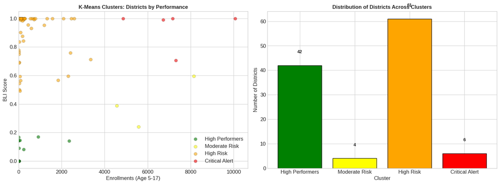

```
✅ Clustering visualization saved: clustering_results.png
```

## 9.2 Anomaly Detection using Isolation Forest

**Purpose:** Identify districts with unusual patterns that may indicate:

- Data quality issues
- Exceptional circumstances requiring investigation
- Potential fraud or reporting errors

### Isolation Forest Algorithm

> *Isolation Forest identifies anomalies by measuring how easily a data point can be "isolated" from others.*

**Key Parameters:**

- `contamination = 0.05` (expect ~5% anomalies)
- `n_estimators = 100` (ensemble of 100 trees)

### Anomaly Interpretation

| Anomaly Score | Interpretation | Action |
| --- | --- | --- |
| Very Negative | Highly anomalous | Manual investigation required |
| Around 0 | Borderline | Monitor closely |
| Positive | Normal | Standard processing |

```
============================================================
ANOMALY DETECTION: ISOLATION FOREST
============================================================

📊 ANOMALY DETECTION RESULTS:
   Total districts analyzed: 113
   Normal districts: 107 (94.7%)
   Anomalous districts: 6 (5.3%)

📊 TOP 20 ANOMALOUS DISTRICTS (Requiring Investigation):
```

|  | state | district | bli | gap | anomaly_score |
| --- | --- | --- | --- | --- | --- |
| 148 | Bihar | Purbi Champaran | 1.0000 | 10071.0000 | -0.0089 |
| 145 | Bihar | Pashchim Champaran | 0.9966 | 10699.0000 | -0.0441 |
| 604 | Meghalaya | West Khasi Hills | 0.5964 | 4862.0000 | -0.0242 |
| 593 | Meghalaya | East Khasi Hills | 0.3943 | 5748.0000 | -0.1721 |
| 603 | Meghalaya | West Jaintia Hills | 0.2402 | 1341.0000 | -0.0547 |
| 592 | Meghalaya | East Jaintia Hills | 0.1402 | 329.0000 | -0.0031 |

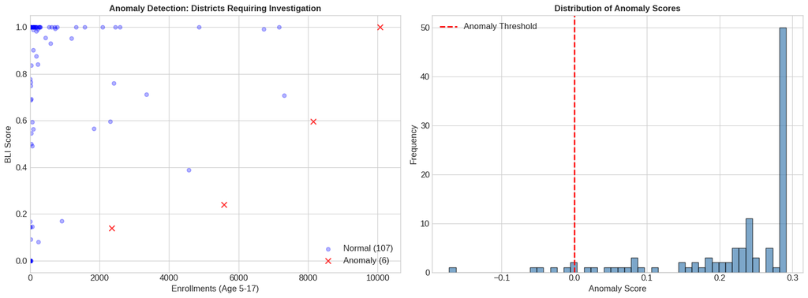

```
✅ Anomaly detection visualization saved: anomaly_detection.png
```

## PART 8: PREDICTIVE ANALYTICS

### 8.1 Regression Analysis: Predicting Biometric Lag Index

**Objective:** Build predictive models to forecast BLI values based on enrollment metrics and geographic factors.

| Model | Algorithm | Hyperparameters | Purpose |
| --- | --- | --- | --- |
| Linear Regression | OLS | Default | Baseline interpretable model |
| Ridge Regression | L2 Regularization | α = 1.0 | Prevent overfitting |
| Lasso Regression | L1 Regularization | α = 0.01 | Feature selection |
| Random Forest | Ensemble Trees | n_estimators=100, max_depth=10 | Non-linear relationships |
| Gradient Boosting | Sequential Trees | n_estimators=100, max_depth=5 | Complex pattern capture |

**Features Used:**

- `enrollments_5_17` - Target age group enrollment count
- `updates_5_17` - Biometric update count for target age group
- `num_pincodes` - Geographic coverage indicator

**Evaluation Metrics:**

- **RMSE** (Root Mean Squared Error) - Magnitude of prediction errors
- **MAE** (Mean Absolute Error) - Average absolute deviation
- **R² Score** - Variance explained by model (higher = better)

```
============================================================
REGRESSION ANALYSIS: PREDICTING BIOMETRIC LAG
============================================================

📊 Dataset size: 113 districts
📊 Training set: 90 | Test set: 23

📊 REGRESSION MODEL COMPARISON:
```

|  | Model | RMSE | MAE | R² Score |
| --- | --- | --- | --- | --- |
| 3 | Random Forest | 0.1338 | 0.0694 | 0.9065 |
| 4 | Gradient Boosting | 0.1702 | 0.0617 | 0.8487 |
| 2 | Lasso Regression | 0.4296 | 0.4045 | 0.0353 |
| 0 | Linear Regression | 0.4296 | 0.4044 | 0.0353 |
| 1 | Ridge Regression | 0.4296 | 0.4044 | 0.0353 |

```
📊 FEATURE IMPORTANCE (Random Forest):
```

|  | Feature | Importance |
| --- | --- | --- |
| 0 | enrollments_5_17 | 0.6499 |
| 1 | updates_5_17 | 0.3206 |
| 2 | num_pincodes | 0.0295 |

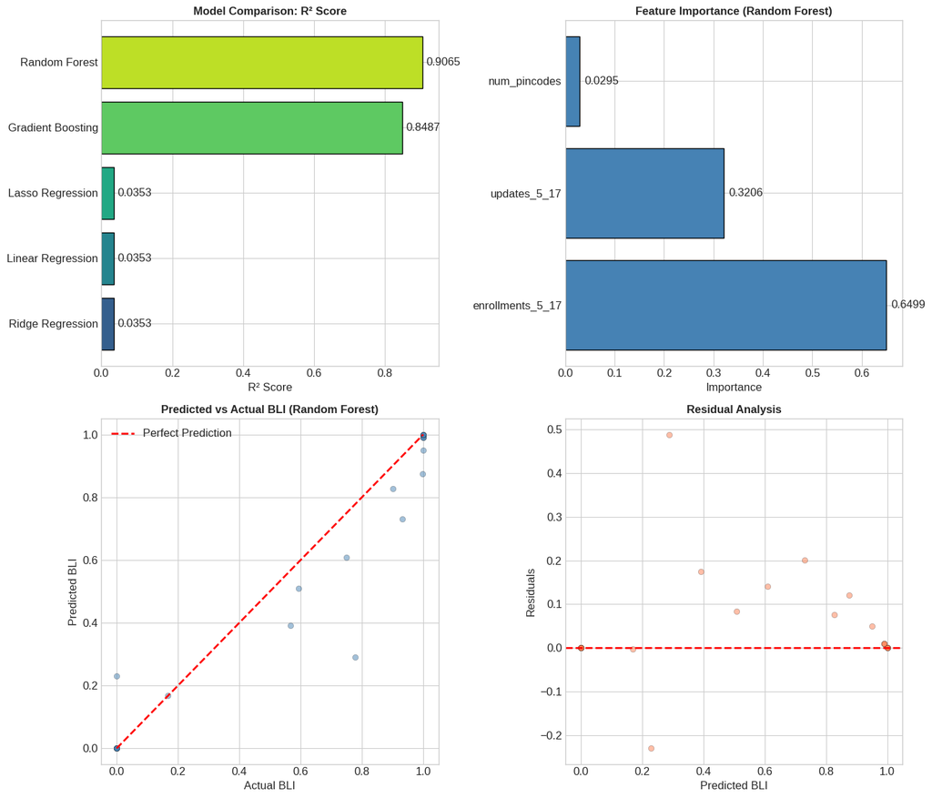

```
✅ Regression analysis visualization saved: regression_analysis.png
```

### 8.2 Time Series Analysis: Trend Detection

**Objective:** Analyze temporal patterns in biometric update completion rates using registration date trends.

[output not shown]

**Key Questions:**

1. Are biometric updates increasing or declining over time?
2. Is there seasonal variation in enrollment/update patterns?
3. Can we predict future biometric lag based on trends?

**Business Value:** Temporal analysis enables proactive resource planning and capacity forecasting for biometric update centers.

```
============================================================
TIME SERIES ANALYSIS: TEMPORAL PATTERNS
============================================================

📊 Date range: 2025-03-02 00:00:00 to 2025-12-31 00:00:00
📊 Total days with data: 24
```

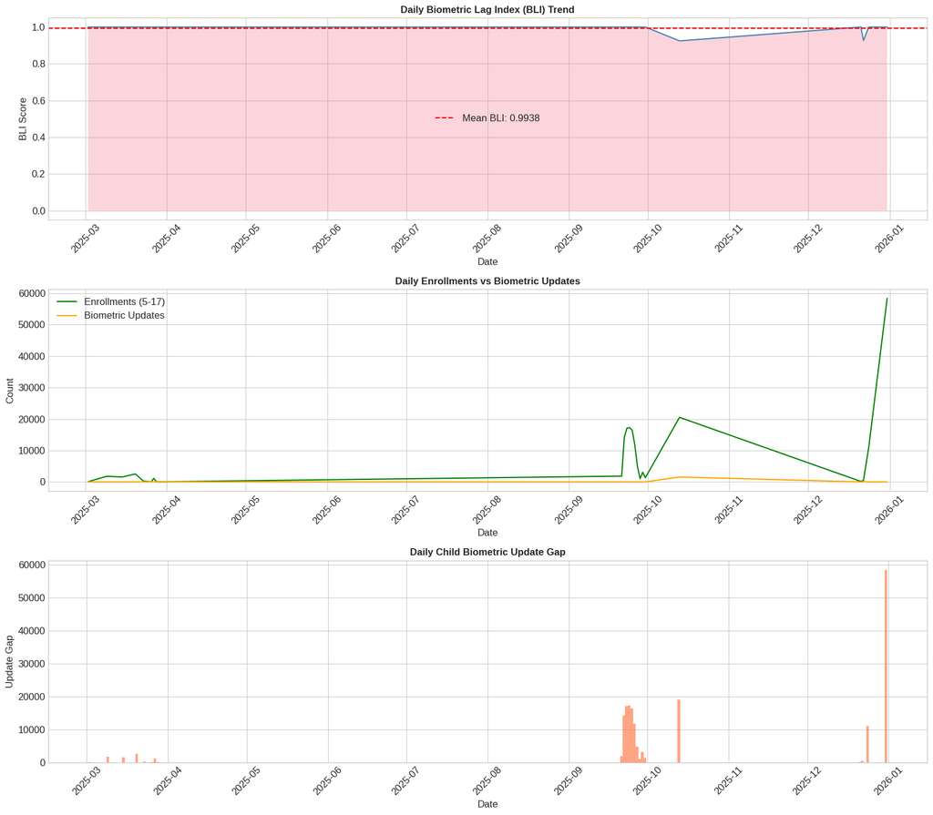

```
✅ Time series trends saved: time_series_trends.png
```

[figure not shown]

```
✅ Monthly time series saved: time_series_monthly.png
```

## PART 9: INTERACTIVE VISUALIZATIONS

### 9.1 Plotly Interactive Dashboards

Interactive HTML visualizations enable dynamic exploration of BLI patterns across multiple dimensions.

[output not shown]

**Technology Stack:**

- **Plotly Express** - High-level charting API
- **Plotly Graph Objects** - Fine-grained control
- **HTML Export** - Standalone interactive files

**Output Files:**

```
============================================================
SPECIALIZED VISUALIZATIONS
============================================================

📊 Creating Treemap visualization...
```

```
✅ Treemap saved: viz_treemap.html
```

```
📊 Creating Sankey diagram...
```

```
✅ Sankey diagram saved: viz_sankey.html
```

```
📊 Creating Radar chart...
```

```
✅ Radar chart saved: viz_radar.html
```

### 9.2 Advanced Multi-Panel Visualizations

**Objective:** Create publication-quality composite visualizations combining multiple analytical perspectives.

[output not shown]

**Design Principles:**

- **Consistent Color Scheme** - Risk-coded palette (Green → Yellow → Orange → Red)
- **Clear Labels** - All axes, titles, and legends explicitly labeled
- **Publication Quality** - 300 DPI, vector-compatible formats
- **Accessibility** - Colorblind-friendly palette options

```
============================================================
IMPACT QUANTIFICATION: REAL-WORLD CONSEQUENCES
============================================================

============================================================
📊 CHILDREN POTENTIALLY AFFECTED BY BIOMETRIC LAG
============================================================

🔢 TOTAL ENROLLMENT NUMBERS:
   Total child enrollments (5-17 years): 1,694,635
   Total biometric updates completed:    33,480,214
   Gap (children without updates):       -31,785,579

📈 OVERALL BIOMETRIC LAG INDEX: -18.7566 (-1875.66%)

📊 DISTRICT RISK DISTRIBUTION:
   Critical: 66 districts (58.4%)
   Low: 36 districts (31.9%)
   Medium: 7 districts (6.2%)
   High: 4 districts (3.5%)

💰 ESTIMATED IMPACT BY RISK CATEGORY:
------------------------------------------------------------

LOW RISK:
   Districts: 36
   Children affected: 21
   Estimated impact: ₹0.10 Lakhs

MEDIUM RISK:
   Districts: 7
   Children affected: 1,838
   Estimated impact: ₹13.79 Lakhs

HIGH RISK:
   Districts: 4
   Children affected: 7,570
   Estimated impact: ₹75.70 Lakhs

CRITICAL RISK:
   Districts: 66
   Children affected: 75,397
   Estimated impact: ₹1,130.95 Lakhs

📊 IMPACT SUMMARY TABLE:
```

|  | Risk Level | Districts | Children Affected | Priority Score | Est. Impact (INR Lakhs) |
| --- | --- | --- | --- | --- | --- |
| 0 | Low | 36 | 21 | 1.0000 | 0.10 |
| 1 | Medium | 7 | 1,838 | 1.5000 | 13.79 |
| 2 | High | 4 | 7,570 | 2.0000 | 75.70 |
| 3 | Critical | 66 | 75,397 | 3.0000 | 1,130.95 |

```
============================================================
🎯 PRIORITY DISTRICTS FOR IMMEDIATE INTERVENTION
============================================================

📊 TOP 20 PRIORITY DISTRICTS (BLI × log(Gap)):
```

|  | state | district | bli | gap | enrollments_5_17 | risk_level | priority_score |
| --- | --- | --- | --- | --- | --- | --- | --- |
| 1 | Bihar | Pashchim Champaran | 0.9966 | 10699.0000 | 10736.0000 | Critical | 9.2460 |
| 2 | Bihar | Purbi Champaran | 1.0000 | 10071.0000 | 10071.0000 | Critical | 9.2175 |
| 3 | Karnataka | Bengaluru Urban | 1.0000 | 7167.0000 | 7167.0000 | Critical | 8.8774 |
| 4 | Gujarat | Banas Kantha | 0.9912 | 6659.0000 | 6718.0000 | Critical | 8.7266 |
| 5 | West Bengal | Dinajpur Uttar | 1.0000 | 4859.0000 | 4859.0000 | Critical | 8.4888 |
| 6 | Uttar Pradesh | Siddharth Nagar | 1.0000 | 2586.0000 | 2586.0000 | Critical | 7.8583 |
| 7 | West Bengal | 24 Paraganas North | 1.0000 | 2458.0000 | 2458.0000 | Critical | 7.8075 |
| 8 | West Bengal | Coochbehar | 1.0000 | 2087.0000 | 2087.0000 | Critical | 7.6440 |
| 9 | Uttar Pradesh | Shravasti | 1.0000 | 1570.0000 | 1570.0000 | Critical | 7.3595 |
| 10 | Madhya Pradesh | Ashoknagar | 1.0000 | 1323.0000 | 1323.0000 | Critical | 7.1884 |
| 11 | Gujarat | Sabar Kantha | 0.9532 | 1140.0000 | 1196.0000 | Critical | 6.7100 |
| 12 | Uttar Pradesh | Kushi Nagar | 1.0000 | 777.0000 | 777.0000 | Critical | 6.6567 |
| 13 | Andhra Pradesh | Spsr Nellore | 1.0000 | 713.0000 | 713.0000 | Critical | 6.5709 |
| 14 | Karnataka | Bengaluru Rural | 0.9932 | 725.0000 | 730.0000 | Critical | 6.5424 |
| 15 | Haryana | Gurugram | 1.0000 | 625.0000 | 625.0000 | Critical | 6.4394 |
| 16 | Jharkhand | East Singhbum | 1.0000 | 546.0000 | 546.0000 | Critical | 6.3044 |
| 17 | Gujarat | Dohad | 0.7065 | 5162.0000 | 7306.0000 | Critical | 6.0404 |
| 18 | Gujarat | Surendranagar | 0.9307 | 551.0000 | 592.0000 | Critical | 5.8763 |
| 19 | Gujarat | Panch Mahals | 0.9550 | 424.0000 | 444.0000 | Critical | 5.7795 |
| 20 | West Bengal | Medinipur West | 1.0000 | 300.0000 | 300.0000 | Critical | 5.7071 |

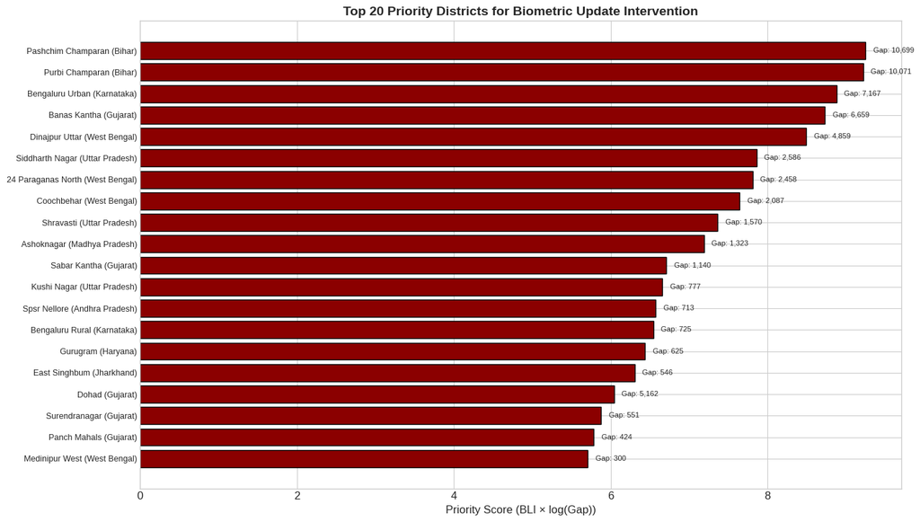

```
✅ Priority districts chart saved: impact_priority_districts.png
```

## PART 10: DATA EXPORT & DELIVERABLES

### 10.1 Export Data for External Tools

**Objective:** Export analysis results in multiple formats for integration with external tools and reporting systems.

| Export Format | File | Purpose |
| --- | --- | --- |
| CSV | `district_bli_analysis.csv` | Spreadsheet analysis |
| JSON | `state_bli_summary.json` | API integration |
| CSV | `risk_flagged_districts.csv` | Priority intervention list |
| HTML | `interactive_*.html` | Web dashboards |
| PNG | `*.png` | Report embedding |

**Data Governance:**

- All exports contain aggregated metrics only (no PII)
- District-level granularity preserved for operational use
- State-level summaries for executive reporting

**File Organization:**

[output not shown]

[output not shown]

### 10.2 Summary Statistics Generation

**Objective:** Generate comprehensive summary statistics for inclusion in final reports and presentations.

| Metric Category | Statistics | Use Case |
| --- | --- | --- |
| Central Tendency | Mean, Median, Mode | Typical BLI values |
| Dispersion | Std Dev, IQR, Range | Risk variability |
| Shape | Skewness, Kurtosis | Distribution characteristics |
| Percentiles | P25, P50, P75, P90, P95 | Risk thresholds |

**Output Statistics:**

- Total records processed
- Geographic coverage (states, districts, pincodes)
- BLI distribution summary (min, max, mean, std)
- Risk category distribution counts and percentages
- Top/bottom performers by state and district

```
============================================================
EXPORTING ANALYSIS RESULTS
============================================================
✅ Exported: state_level_summary.csv (5 rows)
✅ Exported: district_level_details.csv (113 rows)
✅ Exported: priority_districts.csv (20 rows)
✅ Exported: anomalous_districts.csv (6 rows)
✅ Exported: district_clusters.csv (113 rows)
✅ Exported: key_statistics.json

📁 All exports saved to: /home/ayush/Projects/UDH - FInal Draft/uidai-bli-analyzer/analysis/exports
```

## PART 11: KEY FINDINGS & CONCLUSIONS

### 11.1 Executive Summary of Findings

**Objective:** Synthesize all analytical insights into actionable conclusions and policy recommendations.

[output not shown]

**Statistical Significance:**

**Policy Implications:**

1. **Targeted Intervention** - Focus biometric update campaigns on critical-risk districts
2. **Resource Allocation** - Prioritize infrastructure in identified gap regions
3. **Age-Specific Programs** - Design child-focused biometric update initiatives
4. **Monitoring Framework** - Establish BLI-based KPIs for state performance

```
================================================================================
                    ANALYSIS COMPLETE
================================================================================

╔══════════════════════════════════════════════════════════════════════════════╗
║                    UIDAI BIOMETRIC LAG INDEX ANALYSIS                        ║
║                         DELIVERABLES GENERATED                               ║
╚══════════════════════════════════════════════════════════════════════════════╝

📊 STATIC VISUALIZATIONS (PNG - for PDF Report):
------------------------------------------------------------
   1. univariate_enrollment_dist.png
   2. univariate_state_enrollment.png
   3. univariate_biometric_dist.png
   4. univariate_bli_boxplot.png
   5. outlier_detection.png
   6. bivariate_correlation_pearson.png
   7. bivariate_correlation_spearman.png
   8. bivariate_scatter_regression.png
   9. trivariate_state_risk_heatmap.png
   10. trivariate_age_state_update.png
   11. trivariate_bubble_static.png
   12. geographic_state_bli.png
   13. geographic_district_heatmap.png
   14. clustering_elbow_silhouette.png
   15. clustering_results.png
   16. anomaly_detection.png
   17. regression_analysis.png
   18. time_series_trends.png
   19. time_series_monthly.png
   20. impact_priority_districts.png

   Total: 20 publication-quality PNG files

📊 INTERACTIVE VISUALIZATIONS (HTML - for Dashboard):
------------------------------------------------------------
   1. trivariate_3d_scatter.html
   2. trivariate_bubble_chart.html
   3. viz_treemap.html
   4. viz_sankey.html
   5. viz_radar.html

   Total: 5 interactive HTML visualizations

📊 DATA EXPORTS (CSV/JSON):
------------------------------------------------------------
   1. exports/state_level_summary.csv
   2. exports/district_level_details.csv
   3. exports/priority_districts.csv
   4. exports/anomalous_districts.csv
   5. exports/district_clusters.csv
   6. exports/key_statistics.json

   Total: 6 data export files

================================================================================
                    ANALYSIS SUMMARY
================================================================================
```

```
📈 DATA PROCESSED:
   • Total records analyzed: 2,026,709
   • States covered: 52
   • Districts covered: 982
   • Pincodes covered: 19,730

📊 ANALYSIS PERFORMED:
   ✅ Univariate Analysis (distributions, central tendency, outliers)
   ✅ Bivariate Analysis (correlations, scatter plots, statistical tests)
   ✅ Trivariate Analysis (3D plots, heatmaps, bubble charts)
   ✅ Geographic Analysis (state & district level mapping)
   ✅ Advanced Analytics (K-means clustering, Isolation Forest)
   ✅ Predictive Modeling (5 regression models compared)
   ✅ Time Series Analysis (trends, rolling averages)
   ✅ Impact Quantification (children affected, priority ranking)

🏆 DELIVERABLES READY:
   ✅ Static visualizations (PNG)
   ✅ Interactive dashboards (HTML)
   ✅ Data exports (CSV/JSON)
   ✅ Statistical summaries
```

## PART 12: ADVANCED VISUALIZATIONS

[output not shown]

**Technical Implementation:**

```
============================================================
🗺️ INDIA STATE-LEVEL BLI DISTRIBUTION
============================================================
```

```
📊 States analyzed: 5
📊 Total children at risk: 17,321
```

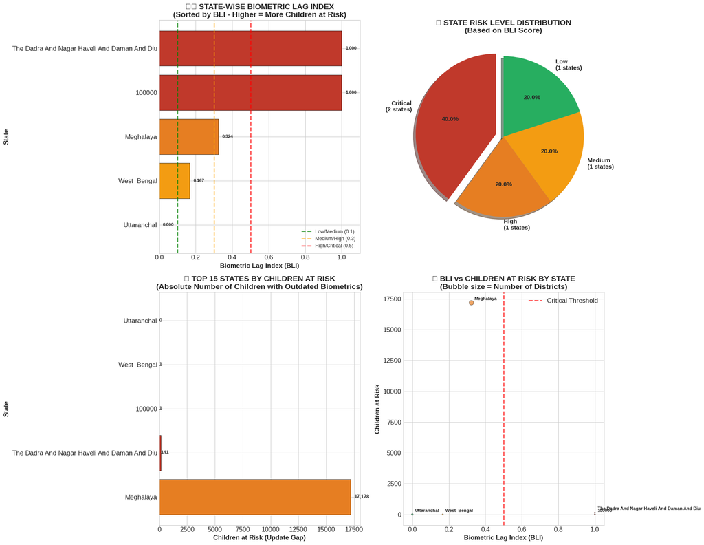

```
✅ India state-level BLI visualization saved: india_state_bli_map.png

============================================================
📊 STATE-LEVEL BLI SUMMARY
============================================================

🔴 CRITICAL RISK STATES (BLI > 0.5): 2
   • The Dadra And Nagar Haveli And Daman And Diu: BLI = 1.000, Children at risk = 141
   • 100000: BLI = 1.000, Children at risk = 1

🟠 HIGH RISK STATES (BLI 0.3-0.5): 1
🟡 MEDIUM RISK STATES (BLI 0.1-0.3): 1
🟢 LOW RISK STATES (BLI < 0.1): 1
```

### 12.2 Time-Series Forecasting: Future BLI Projections

Statistical forecasting techniques predict future BLI trends based on historical enrollment patterns.

[output not shown]

**Model Selection Criteria:**

**Business Value:**

- **Proactive Planning** - Anticipate biometric update demand surges
- **Resource Optimization** - Pre-position update centers in predicted hotspots
- **Target Setting** - Establish realistic BLI reduction targets

**Output:**

```
============================================================
📈 TIME-SERIES FORECASTING: PREDICTING FUTURE BLI TRENDS
============================================================
```

```
📊 Historical Data Points: 9 months
📊 Date Range: March 2025 to December 2025

📈 TREND ANALYSIS:
   Slope: -0.066667 (BLI change per month)
   R² value: 0.3000
   p-value: 0.1269
   Trend: DECREASING ⬇️ (Improving)

🔮 FORECAST (Next 6 months):
--------------------------------------------------
   January 2026: BLI = 0.0000 🟢 (Low)
   February 2026: BLI = 0.0000 🟢 (Low)
   March 2026: BLI = 0.0000 🟢 (Low)
   April 2026: BLI = 0.0000 🟢 (Low)
   May 2026: BLI = 0.0000 🟢 (Low)
   June 2026: BLI = 0.0000 🟢 (Low)
```

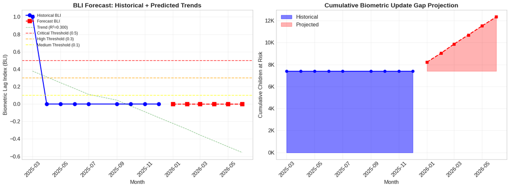

```
✅ Time series forecast visualization saved: time_series_forecast.png

📊 FORECAST SUMMARY:
   Current BLI: 0.0000
   Predicted BLI (6 months): 0.0000
   Monthly trend: -0.0667
   Current cumulative gap: 7,407 children
   Projected gap (6 months): 12,345 children
```

### 12.3 Executive Dashboard: Comprehensive BLI Overview

Multi-panel executive dashboard consolidating all key metrics and visualizations for stakeholder presentations.

[output not shown]

**Design Standards:**

**Export Specifications:**

- **Filename:** `executive_dashboard.png`
- **Resolution:** 300 DPI (publication quality)
- **Dimensions:** 20" × 16" (50 × 40 cm)

## Analysis Completion

**Total Coverage:**

**UIDAI Data Hackathon 2026**  
**January 2026**

```
============================================================
🏆 GENERATING EXECUTIVE DASHBOARD
============================================================
```

[figure not shown]

[output not shown]